# hw4

Name: Sonia Thomas github username: sthomas20

3/1/2020

## Chick weights

The `ChickWeight` data set is part of the base package `datasets`. See `?ChickWeight` for details on the data. For all of the questions use `dplyr` functions with the pipe `%>%` whenever possible.

**Submission instructions**: Create a folder named `ds202_hw4`, and name the RMarkDown file including your solutions `hw4.Rmd` under this folder. For the submission, create a GitHub repository named `ds202_hw4` under your GitHub account, and push both `hw4.Rmd` and the knitted `hw4.html` before the deadline. I will assume you use the same GitHub username as for your HW3 submission. The latest version of your homework appearing on GitHub before the deadline is graded. *It is crucial to follow the exact folder structure and file names*. This homework is **due on March 4** before class.

1. Get a frequency breakdown of the number of chicks, their average weight and the standard deviation of the weights in each of the diets at the start of the study. Store the resulting data frame in a variable named `weight0` and print.

```r
weight0 <- ChickWeight %>%
  filter(Time == 0) %>%
  group_by(Diet) %>%
  summarize(avg_weight = mean(weight, na.rm = TRUE), sd_weight = sd(weight, na.rm = TRUE)) %>%
  print
```

```
## # A tibble: 4 x 3
##   Diet  avg_weight sd_weight
##   <fct>      <dbl>     <dbl>
## 1 1           41.4     0.995
## 2 2           40.7     1.49
## 3 3           40.8     1.03
## 4 4           41       1.05
```

2. Each chick should have twelve weight measurements. Use the `dplyr` package to identify how many measurements are there for each chick. Extract a subset of the data for all chicks with complete information, name the data set `complete`, and print the first 3 rows. (Hint: you might want to use mutate to introduce a helper variable consisting of the number of observations)

```r
ChickWeight %>%
  group_by(Chick) %>%
  summarize(max12 = n()) %>%
  filter(max12 != 12)
```

```
## # A tibble: 5 x 2
##   Chick max12
##   <ord> <int>
## 1 18        2
## 2 16        7
## 3 15        8
## 4 8        11
## 5 44       10
```

```r
complete <- filter(ChickWeight, Chick != 8 & Chick != 15 & Chick != 16 & Chick != 18 & Chick != 44)
head(complete, n=3)
```

```
##   weight Time Chick Diet
## 1     42    0     1    1
## 2     51    2     1    1
## 3     59    4     1    1
```

3. In the complete data set introduce a new variable that measures the current weight difference compared to day 0. Name this variable `weightgain` and print the first 3 rows of the new data frame.

```r
complete<- complete %>%
  group_by(Chick) %>%
  mutate(weightgain = (weight - weight[Time == 0]))

head(complete, n= 3)
```

```
## # A tibble: 3 x 5
## # Groups:   Chick [1]
##   weight  Time Chick Diet  weightgain
##    <dbl> <dbl> <ord> <fct>      <dbl>
## 1     42     0 1     1              0
## 2     51     2 1     1              9
## 3     59     4 1     1             17
```

4. Use `{ggplot2}` to create side-by-side boxplots of `weightgain` by `Diet` for day 21. Change the order of the categories in the Diet variable such that the boxplots are ordered by median `weightgain`, and the lower limit of the y axis should be 0. Describe the relationship in 2-3 sentences.

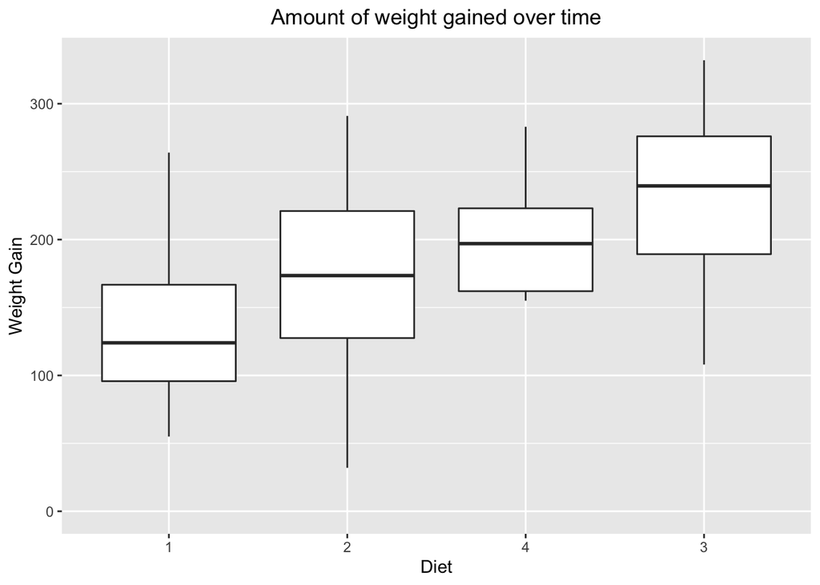

```r
day21<- filter(complete, Time == 21)
one<- tmp <- ggplot(day21, aes(x = reorder(Diet, weightgain, FUN = median), y = weightgain)) + geom_boxplot() + expand_limits(y=0) + xlab("Diet") + ylab("Weight Gain") + ggtitle("Amount of weight gained over time")
one<- one + theme(plot.title = element_text(hjust=0.5))
one
```

The boxplot I think clearly shows that the increase in weight gain as the value of your diet again increases based on looking at the median but breaks after diet 2. I see this because the median for diet 3 is larger than diet 4. You can also see that the diet there has the highest weight gain based on the IQR and the median shown. But I guess who could also see there isn’t an obvious relationship between the the diets but you could say that chicks are prone to more weight gain if diets over 3.

5. Answer each of the following questions using numerical and graphical summary. Also explain what you found: (a) Which chick gained the most weight and which gained the least weight? (b) What diets were they on?

```r
weightGain<- complete %>%
  filter(Time == 21)
print(weightGain)
```

```
## # A tibble: 45 x 5
## # Groups:   Chick [45]
##    weight  Time Chick Diet  weightgain
##     <dbl> <dbl> <ord> <fct>      <dbl>
##  1    205    21 1     1            163
##  2    215    21 2     1            175
##  3    202    21 3     1            159
##  4    157    21 4     1            115
##  5    223    21 5     1            182
##  6    157    21 6     1            116
##  7    305    21 7     1            264
##  8     98    21 9     1             56
##  9    124    21 10    1             83
## 10    175    21 11    1            132
## # … with 35 more rows
```

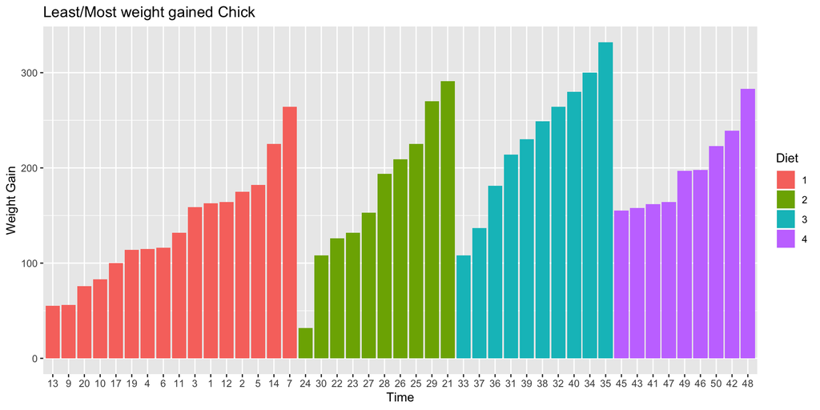

```r
ggplot(weightGain, aes(x=Chick, y = weightgain, fill = Diet)) + geom_col() + xlab("Time") + ylab("Weight Gain") + ggtitle("Least/Most weight gained Chick")
```

Based on the output of both my nummerical and graphical summary you can see that the chick that gained the least amount of weight was chick 24 and was on diet 2 and the chick that gained the most amount of weight was chick 35 and was on diet 3.

6. For the chicks with the least and the most weight at time 0, plot their growth trajectories over time.

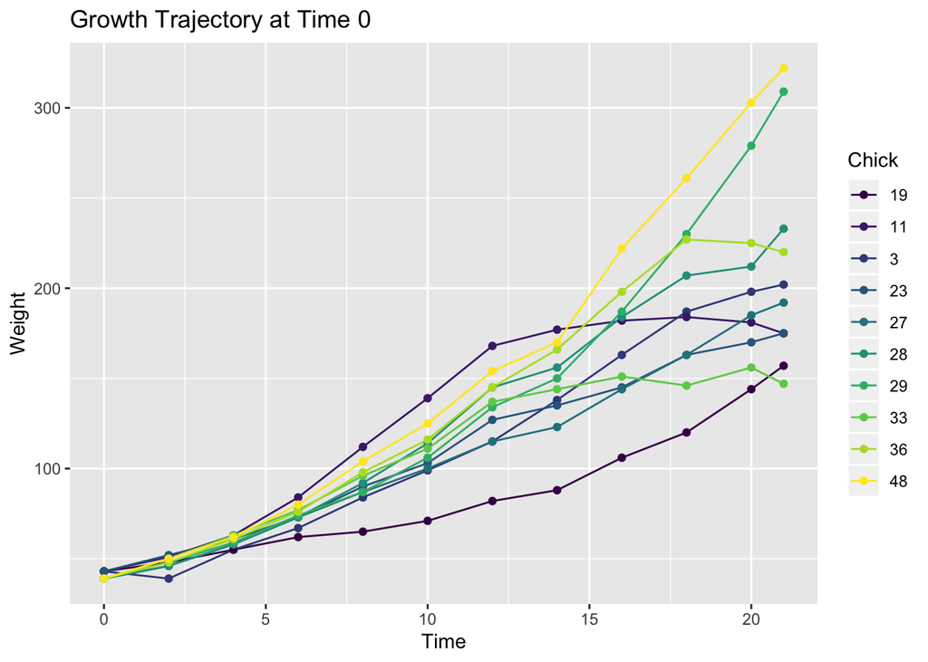

```r
chicks<- complete %>%
  as.data.frame() %>%
  filter(Time == 0) %>%
  filter(weight == max(weight) | weight == min(weight))

newChicks<- chicks %>%
  select(Chick) %>%
  left_join(ChickWeight, by = "Chick")



ggplot(newChicks, aes(x=Time, y=weight, colour= Chick)) + geom_line() + geom_point() + ggtitle("Growth Trajectory at Time 0") + xlab("Time") + ylab("Weight")
```

7. Add to the previous plot the average growth trajectory for all chicks (calculated as the mean weight for each chick at each time). How do the trajectories compare?

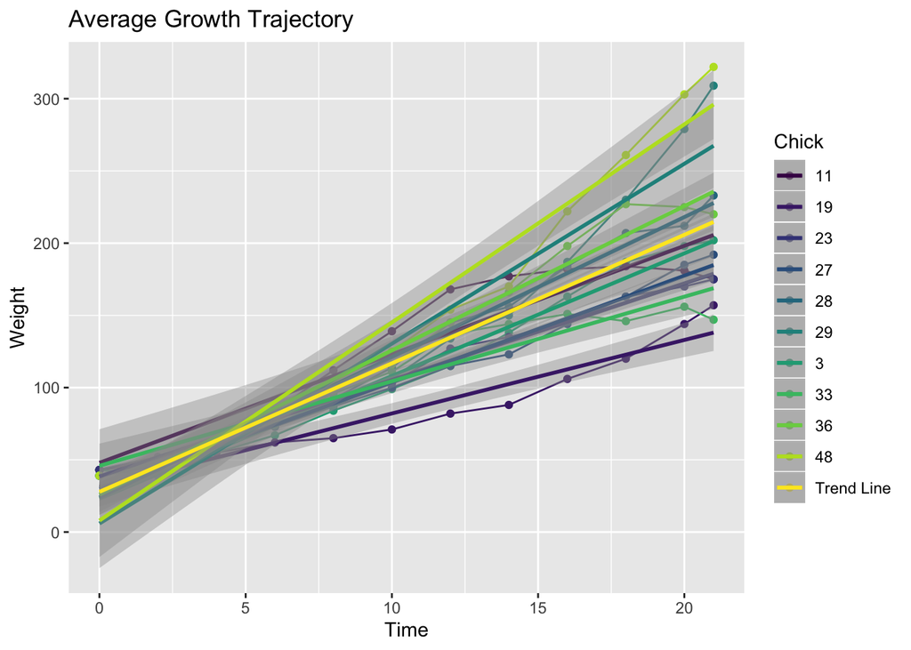

```r
ggplot(newChicks, aes(x=Time, y=weight, colour= Chick)) + geom_line() + geom_point() + ggtitle("Average Growth Trajectory") + xlab("Time") + ylab("Weight") + geom_smooth(method="lm") + geom_smooth(data=complete, aes(x = Time, y = weight, colour="Trend Line"), method="lm")
```

8. What else do you find interesting in the dataset? Show your exploratory analysis.

```r
min<- min(complete$weight)
max<- max(complete$weight)

day1<- complete %>%
  group_by(Chick) %>%
  filter(weight == max | weight == min) %>%
  print
```

```
## # A tibble: 8 x 5
## # Groups:   Chick [8]
##   weight  Time Chick Diet  weightgain
##    <dbl> <dbl> <ord> <fct>      <dbl>
## 1     39     2 3     1             -4
## 2     39     0 27    2              0
## 3     39     0 28    2              0
## 4     39     0 29    2              0
## 5     39     0 33    3              0
## 6    373    21 35    3            332
## 7     39     0 36    3              0
## 8     39     0 48    4              0
```

```r
minMax<- complete %>%
  group_by(Chick) %>%
  filter(Chick == 1 | Chick == 50) %>%
  print
```

```
## # A tibble: 24 x 5
## # Groups:   Chick [2]
##    weight  Time Chick Diet  weightgain
##     <dbl> <dbl> <ord> <fct>      <dbl>
##  1     42     0 1     1              0
##  2     51     2 1     1              9
##  3     59     4 1     1             17
##  4     64     6 1     1             22
##  5     76     8 1     1             34
##  6     93    10 1     1             51
##  7    106    12 1     1             64
##  8    125    14 1     1             83
##  9    149    16 1     1            107
## 10    171    18 1     1            129
## # … with 14 more rows
```

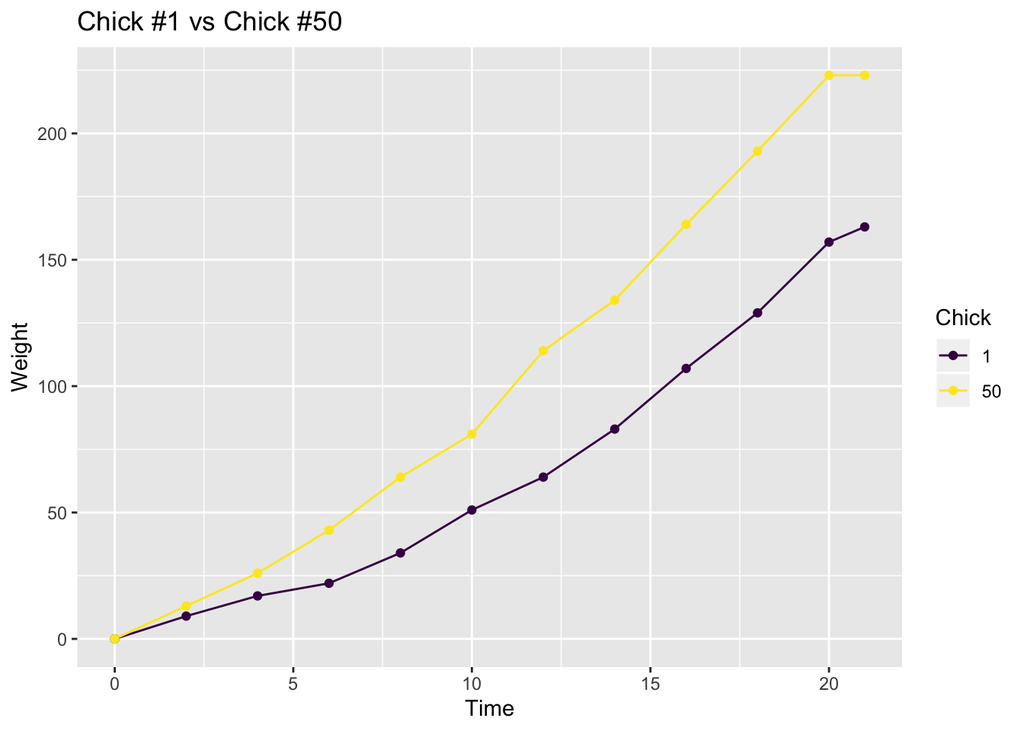

```r
ggplot(minMax, aes(x=Time, y=weightgain, colour= Chick)) + geom_line() + geom_point() + ggtitle("Chick #1 vs Chick #50") + xlab("Time") + ylab("Weight")
```

In this above plot I wanted to see how the highest numbered chick compared to lowest numbered chick in the complete data set which in this case you can see that its chick 1 and chick 50. You can clearly which chick weighs more and has the most weight gain. But in terms of how constant the weight gain is it seems to be about the same.

Note: your submission is supposed to be fully reproducible, i.e. the TA and I will ‘knit’ your submission in RStudio.